# Project 2

Ifeoma Ojialor 10/16/2020

## Introduction

In this project, we will use a bike-sharing dataset to create machine learning models. Before moving forward, I will briefly explain the bike-sharing system and how it works. A bike-sharing system is a service in which users can rent/use bicycles on a short term basis for a fee. The goal of these programs is to provide affordable access to bicycles for short distance trips as opposed to walking or taking public transportation. Imagine how many people use these systems on a given day, the numbers can vary greatly based on some elements. The goal of this project is to build a predictive model to find out the number of people that use these bikes in a given time period using available information about that time/day. This in turn, can help businesses that oversee this systems to manage them in a cost efficient manner.  
We will be using the bike-sharing dataset from the UCL Machine Learning Repository. We will use the regression and boosted tree method to model the response variable `cnt`.

## Exploratory Data Analysis

First we will read in the data using a relative path.

```r
#read in data and filter to desired weekday
day1 <- read.csv("Bike-Sharing-Dataset/day.csv")
head(day1,5)
```

```
##   instant     dteday season yr mnth holiday
## 1       1 2011-01-01      1  0    1       0
## 2       2 2011-01-02      1  0    1       0
## 3       3 2011-01-03      1  0    1       0
## 4       4 2011-01-04      1  0    1       0
## 5       5 2011-01-05      1  0    1       0
##   weekday workingday weathersit     temp
## 1       6          0          2 0.344167
## 2       0          0          2 0.363478
## 3       1          1          1 0.196364
## 4       2          1          1 0.200000
## 5       3          1          1 0.226957
##      atemp      hum windspeed casual registered
## 1 0.363625 0.805833  0.160446    331        654
## 2 0.353739 0.696087  0.248539    131        670
## 3 0.189405 0.437273  0.248309    120       1229
## 4 0.212122 0.590435  0.160296    108       1454
## 5 0.229270 0.436957  0.186900     82       1518
##    cnt
## 1  985
## 2  801
## 3 1349
## 4 1562
## 5 1600
```

Next, we will remove the *casual* and *registered* variables since the `cnt` variable is a combination of both.

```r
day1 <- select(day1, -casual, -registered)
day <- filter(day1, weekday == params$days)

#Check for missing values
miss <- data.frame(apply(day,2,function(x){sum(is.na(x))}))
names(miss)[1] <- "missing"
miss
```

```
##            missing
## instant          0
## dteday           0
## season           0
## yr               0
## mnth             0
## holiday          0
## weekday          0
## workingday       0
## weathersit       0
## temp             0
## atemp            0
## hum              0
## windspeed        0
## cnt              0
```

There are no missing values in the dataset, so we can continue with our analysis.

```r
#Change the variables into their appropriate format.
day$season <- as.factor(day$season)
day$weathersit <- as.factor(day$weathersit)
day$holiday <- as.factor(day$holiday)
day$workingday <- as.factor(day$workingday)
day$weekday <- as.factor(day$weekday)
day$yr <- as.factor(day$yr)
day$mnth <- as.factor(day$mnth)
levels(day$season) <- c("winter", "spring", "summer", "fall")
levels(day$yr) <- c("2011", "2012")
str(day)
```

```
## 'data.frame':    104 obs. of  14 variables:
##  $ instant   : int  6 13 20 27 34 41 48 55 62 69 ...
##  $ dteday    : chr  "2011-01-06" "2011-01-13" "2011-01-20" "2011-01-27" ...
##  $ season    : Factor w/ 4 levels "winter","spring",..: 1 1 1 1 1 1 1 1 1 1 ...
##  $ yr        : Factor w/ 2 levels "2011","2012": 1 1 1 1 1 1 1 1 1 1 ...
##  $ mnth      : Factor w/ 12 levels "1","2","3","4",..: 1 1 1 1 2 2 2 2 3 3 ...
##  $ holiday   : Factor w/ 2 levels "0","1": 1 1 1 1 1 1 1 1 1 1 ...
##  $ weekday   : Factor w/ 1 level "4": 1 1 1 1 1 1 1 1 1 1 ...
##  $ workingday: Factor w/ 2 levels "0","1": 2 2 2 2 2 2 2 2 2 2 ...
##  $ weathersit: Factor w/ 3 levels "1","2","3": 1 1 2 1 1 1 1 2 1 3 ...
##  $ temp      : num  0.204 0.165 0.262 0.195 0.187 ...
##  $ atemp     : num  0.233 0.151 0.255 0.22 0.178 ...
##  $ hum       : num  0.518 0.47 0.538 0.688 0.438 ...
##  $ windspeed : num  0.0896 0.301 0.1959 0.1138 0.2778 ...
##  $ cnt       : int  1606 1406 1927 431 1550 1538 2475 1807 1685 623 ...
```

### Univariate Analysis

The `cnt` is the response variable, so we’ll use a histogram to get a visual understanding of the variable.

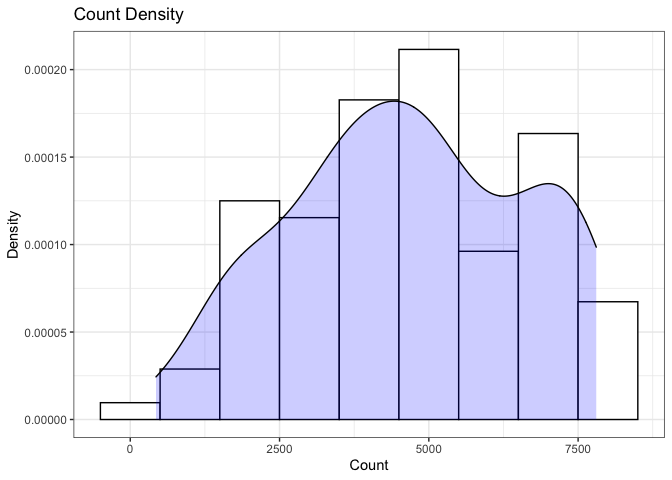

```r
ggplot(day, aes(x = cnt)) + theme_bw() + geom_histogram(aes(y =..density..), color = "black", fill = "white", binwidth = 1000) + geom_density(alpha = 0.2, fill = "blue") + labs(title = "Count Density", x = "Count", y = "Density")
```

```r
summary(day$cnt)
```

```
##    Min. 1st Qu.  Median    Mean 3rd Qu.    Max.
##     431    3271    4721    4667    6286    7804
```

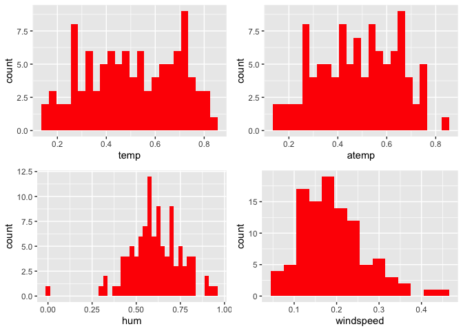

```r
#visualize numeric predictor variables using a histogram
p1 <- ggplot(day) + geom_histogram(aes(x = temp), fill = "red", binwidth = 0.03)
p2 <- ggplot(day) + geom_histogram(aes(x = atemp), fill = "red", binwidth = 0.03)
p3 <- ggplot(day) + geom_histogram(aes(x = hum), fill = "red", binwidth = 0.025)
p4 <- ggplot(day) + geom_histogram(aes(x = windspeed), fill = "red", binwidth = 0.03)
gridExtra::grid.arrange(p1,p2,p3,p4, nrow = 2)
```

Observations: * No clear cut pattern in `temp`and `atemp`.

- `hum` appears to be skewed to the left when the dataset is not filtered to a specific weekday.
- `windspeed` appears to be skewed(right). This variable should be transformed to curb its skewness.
- The distribution of `temp` and `atemp` looks very similar. We should think about taking out one of the variables.

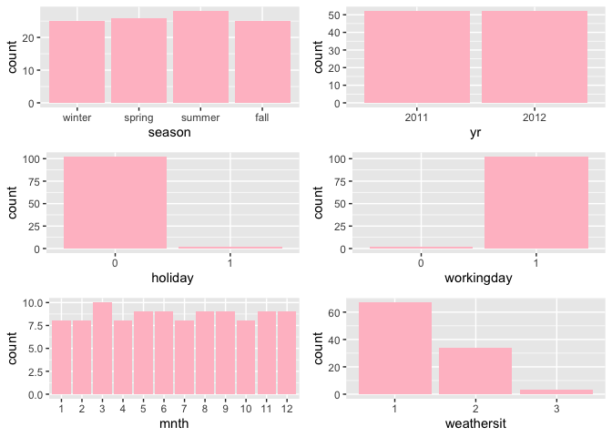

```r
#visualize categorical predictor variables
h1 <- ggplot(day) + geom_bar(aes(x = season),fill = "pink")
h2 <- ggplot(day) + geom_bar(aes(x = yr),fill = "pink")
h3 <- ggplot(day) + geom_bar(aes(x = holiday),fill = "pink")
h4 <- ggplot(day) + geom_bar(aes(x = workingday),fill = "pink")
h5 <- ggplot(day) + geom_bar(aes(x = mnth),fill = "pink")
h6 <- ggplot(day) + geom_bar(aes(x = weathersit),fill = "pink")
gridExtra::grid.arrange(h1,h2,h3,h4,h5,h6, nrow = 3)
```

Observations: * The variation between the four seasons is little to none.

- About the same number of people rode bikes in 2011 and 2012.
- Many people rode bikes on days that are not holidays.
- Most people used the bike-sharing system on days that were neither weekends nor holidays.
- Most people used the bike sharing system on days with clear weather.

### Bi-variate Analysis

In this section, we will explore the predictor variables with respect to the response variable. The objective is to discover hidden relationships between the independent and response variables and use those findings in the model building process.

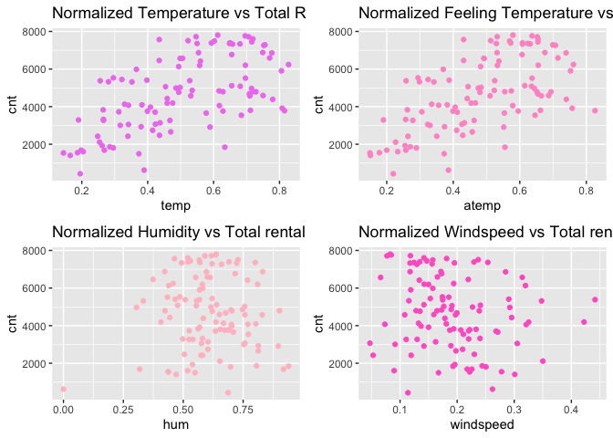

```r
# First, we will explore the relationship between the target and numerical variables.
p1 <- ggplot(day) +geom_point(aes(x = temp, y = cnt), colour = "violet") + labs(title = "Normalized Temperature vs Total Rental Bikes")
p2 <- ggplot(day) +geom_point(aes(x = atemp, y = cnt), colour = "#FF99CC") +labs(title = "Normalized Feeling Temperature vs Total Rental Bikes")
p3 <- ggplot(day) +geom_point(aes(x = hum, y = cnt), colour = "pink") + labs(title = "Normalized Humidity vs Total rental Bikes")
p4 <- ggplot(day) +geom_point(aes(x = windspeed, y = cnt), colour = "#FF66CC") +labs(title= "Normalized Windspeed vs Total rental Bikes")
gridExtra::grid.arrange(p1, p2, p3, p4, nrow = 2)
```

Observations: * There appears to be a positive linear relationship between `cnt` , `temp`, and `atemp`.

- There is also a weak relationship between `cnt`, `hum`, and `windspeed`.

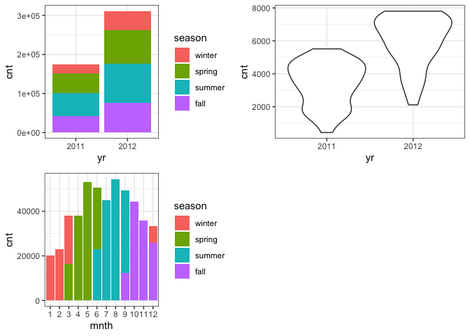

```r
# Now we'll visualize the relationship between the target and categorical variables.
# Instead of using a boxplot, I will use a violin plot which is the blend of both a boxplot and density plot
g1 <- ggplot(day) + geom_col(aes(x = yr, y = cnt, fill = season))+theme_bw()
g2 <- ggplot(day) + geom_violin(aes(x = yr, y = cnt))+theme_bw()
g3 <- ggplot(day) + geom_col(aes(x = mnth, y = cnt, fill = season))+theme_bw()
g4 <- ggplot(day) + geom_col(aes(x = holiday, y = cnt, fill = season)) + theme_bw()
g6 <- ggplot(day) + geom_col(aes(x = workingday, y = cnt, fill = season))
g7 <- ggplot(day) + geom_col(aes(x = weathersit, y = cnt, fill = season))
gridExtra::grid.arrange(g1, g2, g3, nrow = 2)
```

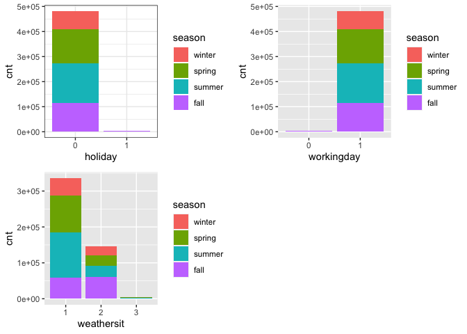

```r
gridExtra::grid.arrange(g4, g6, g7, nrow = 2)
```

Observations: * The total bike rental count is higher in 2012 than 2011.

- During workingday, the bike rental counts quite the highest compared to during no working day for different seasons.
- During clear,partly cloudy weather, the bike rental count is highest and the second highest is during mist cloudy weather and followed by third highest during light snow and light rain weather.
- The highest bike rental count was during the summer and lowest in the winter.

## Correlation Matrix

Correlation matrix helps us to understand the linear relationship between variables.

```r
day_c <- day[ , c(10:14)]
round(cor(day_c), 2)
```

```
##            temp atemp   hum windspeed   cnt
## temp       1.00  1.00  0.15     -0.11  0.60
## atemp      1.00  1.00  0.15     -0.12  0.61
## hum        0.15  0.15  1.00     -0.31  0.00
## windspeed -0.11 -0.12 -0.31      1.00 -0.18
## cnt        0.60  0.61  0.00     -0.18  1.00
```

From the above matrix, we can see that `temp` and `atemp` are highly correlated. So we only need to include one of these variables in the model to prevent multicollinearity. We will also transform the humidity and windspeed variable.

```r
day <- mutate(day, log_hum = log(day$hum+1))
day <- mutate(day, log_ws = log(day$windspeed + 1))

#Remove irrelevant variables
day <- select(day, -weekday,-holiday,-workingday,-dteday,-temp, -instant)
```

## Model Building

First we split the data into train and test sets.

```r
set.seed(23)
dayIndex<- createDataPartition(day$cnt, p = 0.7, list=FALSE)
dayTrain <- day[dayIndex, ]
dayTest <- day[-dayIndex, ]

# Build a tree-based model using loocv;
fitTree <- train(cnt~ ., data = dayTrain, method = "rpart",
              preProcess = c("center", "scale"),
              trControl = trainControl(method = "loocv", number = 10), tuneGrid = NULL)
# Display information from the tree fit
fitTree$results
```

```
##          cp     RMSE Rsquared      MAE   RMSESD
## 1 0.1623048 1094.253      NaN 1094.253 654.7690
## 2 0.2128773 1338.501      NaN 1338.501 800.1816
## 3 0.4540853 2025.910      NaN 2025.910 917.6932
##   RsquaredSD    MAESD
## 1         NA 654.7690
## 2         NA 800.1816
## 3         NA 917.6932
```

```r
# Build a boosted tree model using cv
fitBoost <- train(cnt~., data = dayTrain, method = "gbm",
              preProcess = c("center", "scale"),
              trControl = trainControl(method = "cv", number = 10),
              tuneGrid = NULL)
# Display information from the boost fit
fitBoost$results
```

```
##   shrinkage interaction.depth n.minobsinnode
## 1       0.1                 1             10
## 4       0.1                 2             10
## 7       0.1                 3             10
## 2       0.1                 1             10
## 5       0.1                 2             10
## 8       0.1                 3             10
## 3       0.1                 1             10
## 6       0.1                 2             10
## 9       0.1                 3             10
##   n.trees     RMSE  Rsquared      MAE   RMSESD
## 1      50 844.1305 0.8736937 708.4486 257.7602
## 4      50 886.8888 0.8522844 727.8371 240.1523
## 7      50 882.1262 0.8562013 725.0814 263.7859
## 2     100 832.0928 0.8726336 696.2348 240.6215
## 5     100 890.4470 0.8486615 719.0385 201.4186
## 8     100 879.1062 0.8504655 715.0794 245.1105
## 3     150 830.2909 0.8763369 690.4309 236.7493
## 6     150 916.3451 0.8421880 745.4908 173.1569
## 9     150 887.3243 0.8472369 729.8468 216.9163
##   RsquaredSD    MAESD
## 1 0.06056947 242.1558
## 4 0.06220548 215.7860
## 7 0.05722550 242.0016
## 2 0.05454529 215.3977
## 5 0.05837817 181.9370
## 8 0.05811878 216.6798
## 3 0.05368148 208.6918
## 6 0.05702456 155.0466
## 9 0.04621794 193.5819
```

Now, we make predictions on the test data sets using the best model fits. Then we compare RMSE to determine the best model.

```r
predTree <- predict(fitTree, newdata = select(dayTest, -cnt))
postResample(predTree, dayTest$cnt)
```

```
##         RMSE     Rsquared          MAE
## 1272.5431392    0.5972237 1021.9454450
```

```r
boostPred <- predict(fitBoost, newdata = select(dayTest, -cnt))
postResample(boostPred, dayTest$cnt)
```

```
##       RMSE   Rsquared        MAE
## 944.280587   0.750086 739.047512
```

When we compare the two models, the boosted tree model have lower RMSE values when applied on the test dataset.